# C. elegans Neuronal Network

## Data Analysis

There have been a work on the properties of the neuronal network based on these incomplete or inconsistent wiring diagrams. Varshney et al(2011) proposed ``near-complete" wiring diagram of C. elegans. They are interested in local network properties as well as global network properties. We can naturally think that neuronal physical networks and some of the biological function or properties would be correlated each other.

We are given a connected, weighted and also directed network of C. elegans, which is comprised of 279 nodes and 3225 (directed) edges between them. The given network illustrates the network in the region of pharynx, and the weight imposed on each edge is equivalent to the number of corresponding synapses. For vertex attributes, we have (1) cell class, (2) soma position, (3) neurotransmitters and (4) role. (1) Cell class can be considered as a categorical variable with 108 categories-that is pretty large number of categories.

```r
#table(V(elegans)$cell_class)
```

The second vertex attribute, (2) soma position looks like a continuous variable. The distribution of the position is shown below.

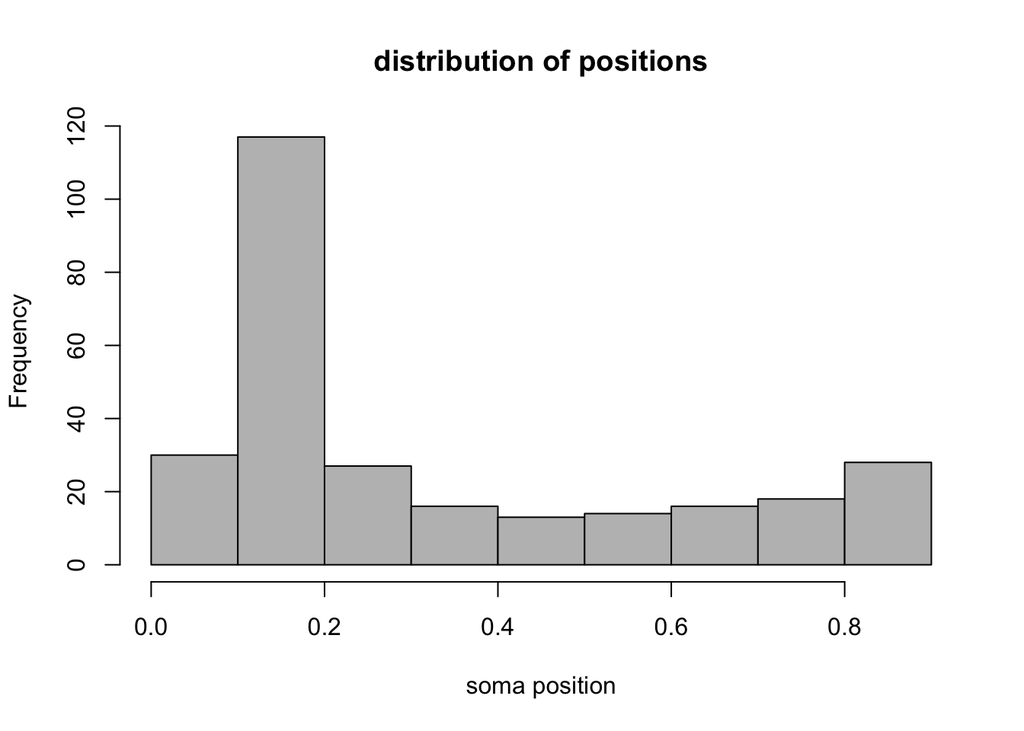

Bad news about (3) neurotransmitters is that we have 161(58$\%$) missing values. We also have 92(32$\%$) missing in (4) role, too. Even if we treat it as another category, it still remains a problem on how to measure the distance within categorical variables. Different from the continuous cases, different values that a categorical attribute takes are not inherently ordered.

## Dependence between Neuronal Network vs. Soma Position

Two types of distance matrix has been uses here.

- $\textbf{A}$ : Distance matrix based on an adjacency matrix of $A$ for which $A_{ij} = 0$ if and only if there exists an edge from node $i$ to node $j$; $A_{ij} = 1$ if they are NOT adjacent each other.
- $\textbf{A'}$ Geodesic distance matrix $A$ weighted by the count of synapses, using Dijkstra algorithm.
- $\textbf{B}$ : $B_{ij} = (1 - \exp(-|X_{i} - X_{j}|)) / \max(B_{ij} ; i,j = 1,...,n)$
- $\textbf{B'}$ : Euclidean distance matrix of soma position.
- $\tilde{A} = H A H$ for all matrix $A$
- Goal : Test $H_{0} : f_{AB} = f_{A}f_{B}$

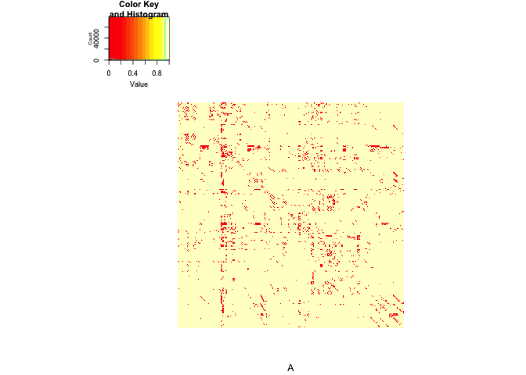

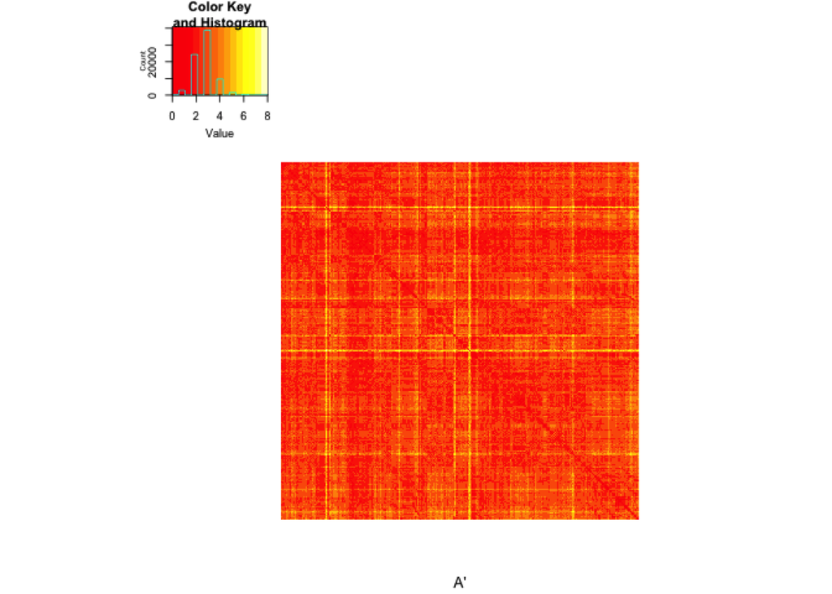

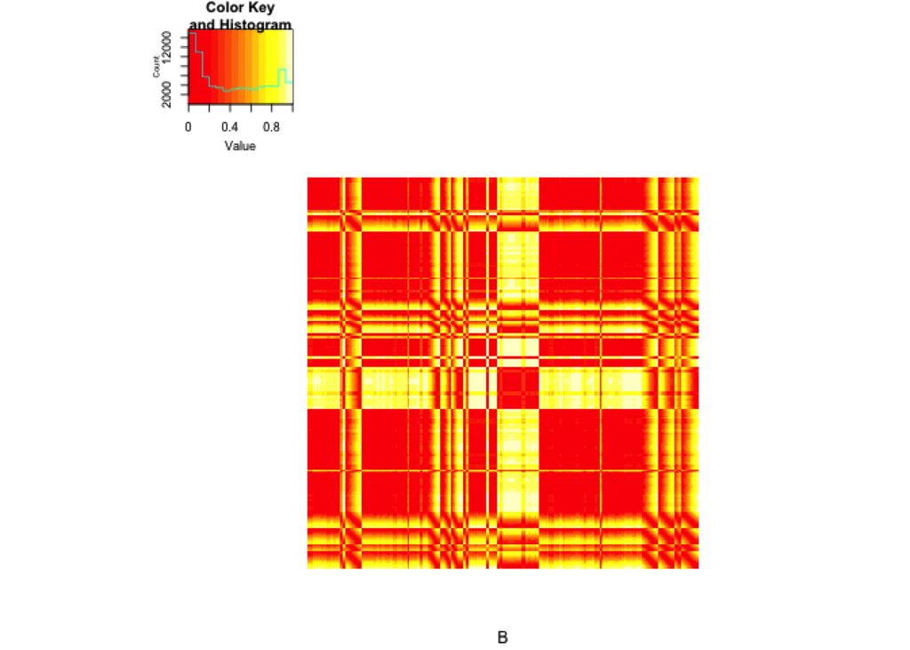

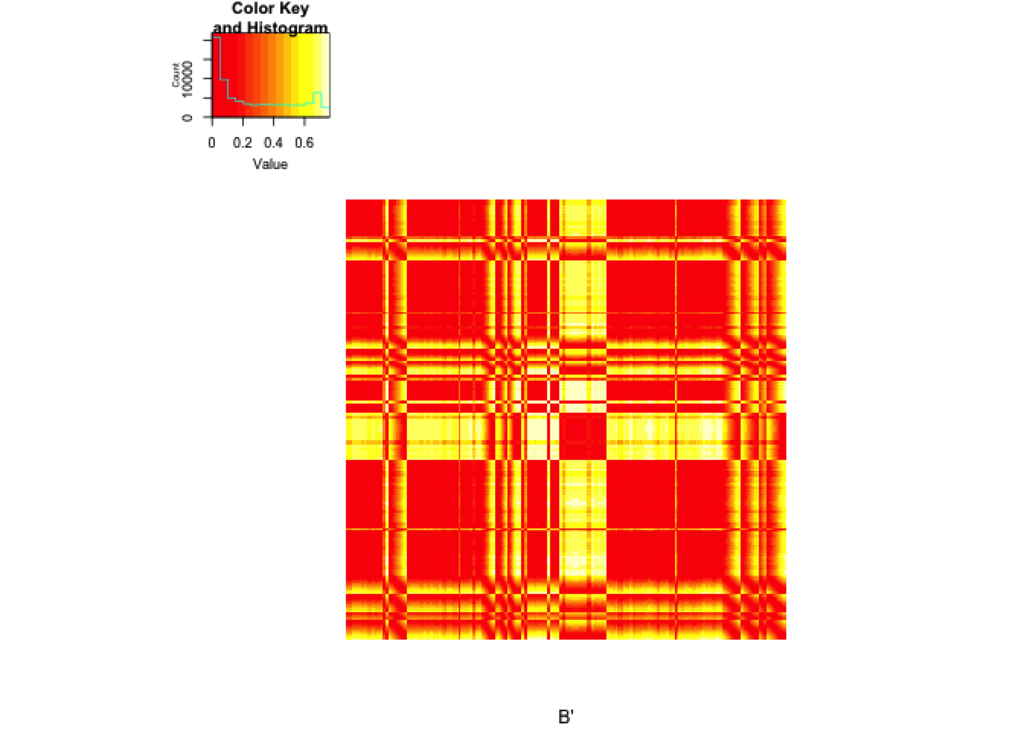

## Dependence between Neuronal Network vs. Cell type

- Goal : Test $H_{0} : f_{AC} = f_{A}f_{C}$

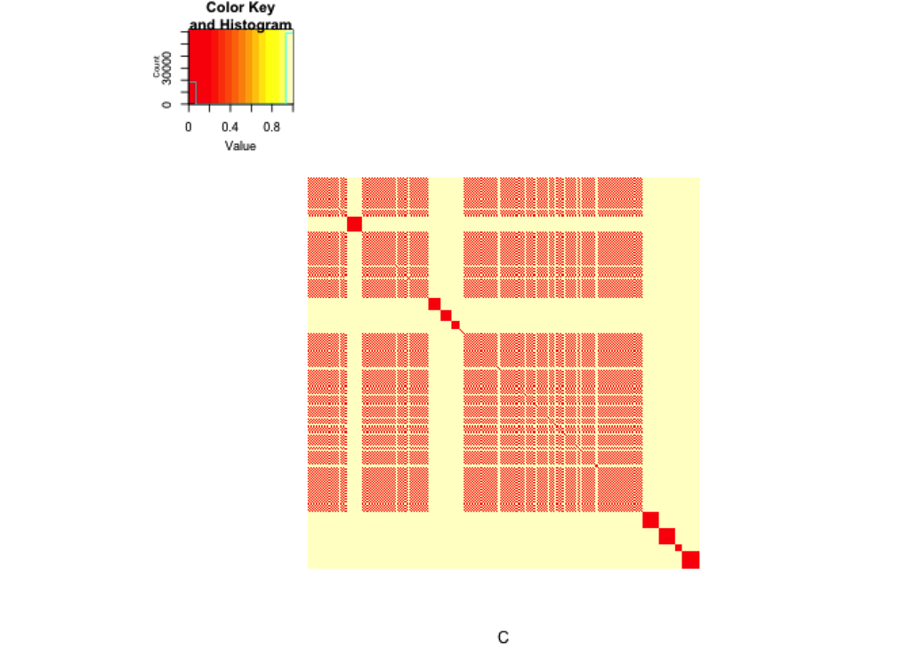

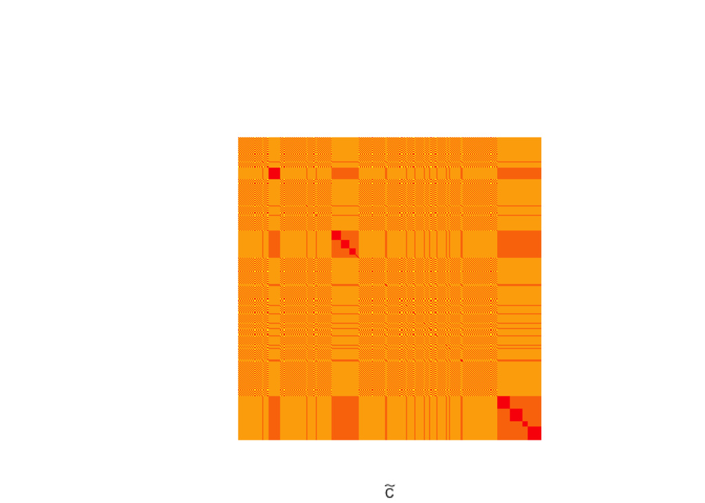

### P-value Heatmap

- $A'$ vs $B'$

Geodesic Distance Matrix of neuronal network vs. Euclidean Distance Matrix of soma position

We have only one single value of all local test. The resulting the local p-value heat map shows that the local scales have significant p-values for neuronal connectivity vs. soma position in Euclidean distance measure.

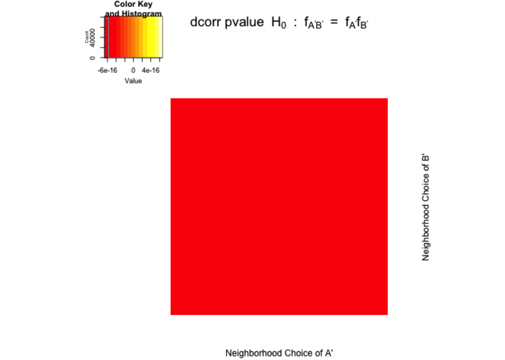

## Subnetwork

Let’s consider two categories in cell - “R”ight and “L”eft. Because 90 out of 279 nodes do not have information whether they are right or left, We can only consider a induced subnetwork comprised of 189 nodes. Let $A_{s}$ be a similarity matrix of sub-network and $A'_{s}$ be a geodesic distance matrix of subnetwork. Note that $A_{s}$ can be defined as a sub-matrix of $A,$ but how to define $A'_{s}$ can be flexible - depending on whether you take account 90 nodes in calculating geodesic distance or not. I assume that a full network of 279 nodes well reflects all the connectivity, so include other 90 nodes in possible paths. Thus, $A'_{s}$ can be also defined as a sub-matrix of $A'.$

Let $D$ be a distance matrix of cell direction.

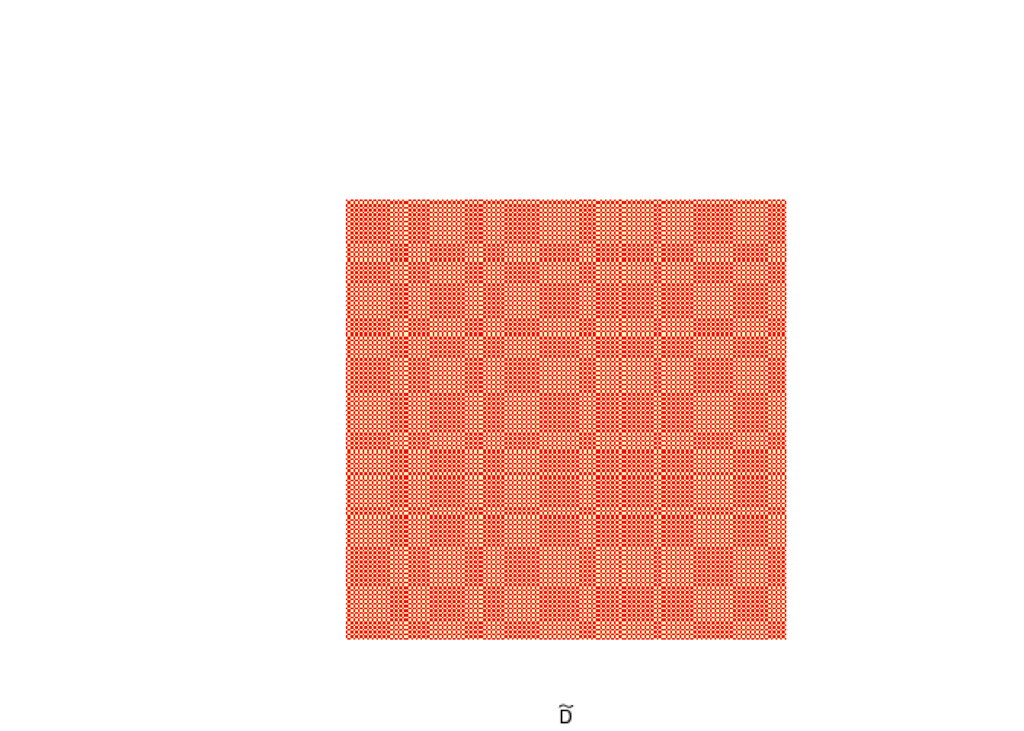

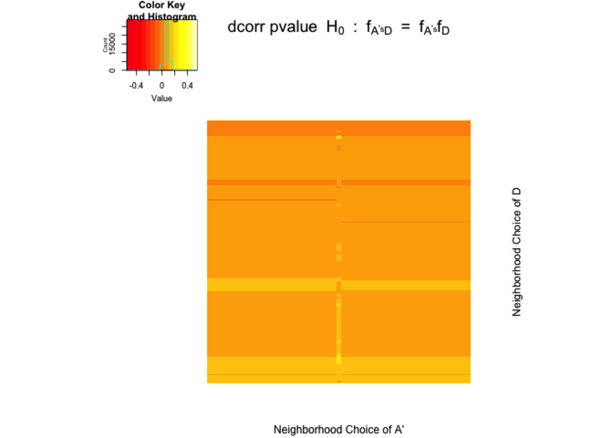